# Final R Scripts & Plots

Archana Raghu

December 5, 2017

## R Markdown

## Teachers with Masters Degreee - District Wise

This plot is regarding the percentage of teacherrs with masters degreee in each district. From the plot we can also interpret the change in teachers who have masters degree.

```r
library(ggplot2)
#install.packages("moments")
library(moments)
#install.packages("ggplot2")
library(readxl)
#library(ggplot2)
```

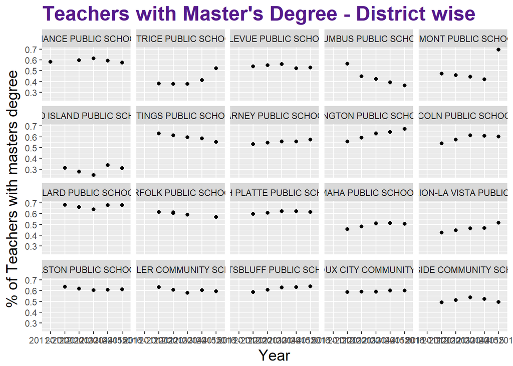

[figure not shown]

```r
q2 <- readxl::read_xlsx("Master.xlsx")
pl2 <- ggplot(q2,aes(x=q2$`School Year`,y=q2$`Teachers with Masters Degree`))+geom_point() + facet_wrap(~q2$`Agency Name`)
pl2 + labs(title="Teachers with Master's Degree - District wise",x="Year", y="% of Teachers with masters degree" ) + theme(plot.title = element_text(size = 20, face = "bold",color = "purple4"),axis.title.x = element_text(vjust = 10,size = 15),axis.title.y = element_text(size = 15))
```

## Attendance Rate vs Dropout Rate

In this plot, i had used ggplot to obtain plot on Attendance rate vs Dropout Rate. We can interpret that the attendance had an impact on the dropout rate which is known fact. The lower the absence percecntage the lower was the dropout rate.

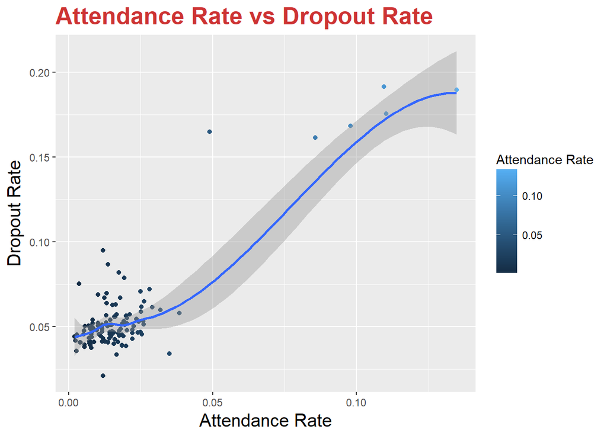

```r
q4 <- readxl::read_xlsx("ques 2.xlsx")
pl3 <- ggplot(q4,aes(x=`Attendance Rate`,y=`Dropout Rate`))
pl3.1 <- pl3 + geom_point(aes(color=`Attendance Rate`)) + geom_smooth()
pl3.1 + labs(title="Attendance Rate vs Dropout Rate") +theme(plot.title = element_text(size = 20, face = "bold",color = "brown3"),axis.title.x = element_text(vjust = 10,size = 15),axis.title.y = element_text(size = 15))
```

## Including Plots

[figure not shown]

## Attendance Rate vs Dropout Rate - District Wise So in this pot we can figure out the district wise performance of schools and how the attendance rate had impact on their dropout rate.

[figure not shown]

```
set1data <- read.csv("Set 1.csv",stringsAsFactors = FALSE)

str(set1data)

head(set1data)

set1data$ï..Type <- factor(set1data$ï..Type)
set1data$DataYears <- factor(set1data$DataYears)
set1data$County <- factor(set1data$County)
set1data$District <- factor(set1data$District)
set1data$School <- factor(set1data$School)
set1data$Agency.Name <- factor(set1data$Agency.Name)
set1data$Subject <- factor(set1data$Subject)
set1data$Grade_Code <- factor(set1data$Grade_Code)
set1data$Category <- factor(set1data$Category)
set1data$AYP.Group <- factor(set1data$AYP.Group)
set1data$Standard.Code <- factor(set1data$Standard.Code)
set1data$Standard <- factor(set1data$Standard)

str(set1data)

head(set1data)

summary(set1data$Standard.Correct.Percent)
```

```
install.packages("moments");
library(moments);
skewness(set1data$Standard.Correct.Percent);#Positive Skewness means right tail is longer
kurtosis(set1data$Standard.Correct.Percent);#Positive Kurtosis means more outliers are present

install.packages("ggplot2");
library("ggplot2");
```

```r
q4 <- readxl::read_xlsx("ques 2.xlsx")
pl4 <- ggplot(q4,aes(q4$`Attendance Rate`,q4$`Dropout Rate`)) + geom_point() + facet_wrap(~q4$`Agency Name`)
pl4.1 <- pl4 + labs(title="Attendance Rate vs Dropout Rate", x="Attendance Rate", y="Dropout Rate") +theme(plot.title = element_text(size = 20, face = "bold",color = "orangered1"),axis.title.x = element_text(vjust = 10,size = 15),axis.title.y = element_text(size = 15))
```

# uses violin to build density to identified bimodality (more than one mode)

# Splits the data set into District, State, School.

```
subjectlist <- split(set1data, set1data$Type)
summary(subjectlist)
```

# 1 = District

# 2 = School

# 3 = State

# Plots the Boxplot and violin plot for State level, by Subject

```r
setwd("D:/Downloads/Fall 2017/DTD")
set1data <- read.csv("Set 1.csv",stringsAsFactors = FALSE)

str(set1data)
```

```
## 'data.frame':    120350 obs. of  15 variables:
##  $ Type                    : chr  "ST" "ST" "ST" "ST" ...
##  $ DataYears               : chr  "2015-2016" "2015-2016" "2015-2016" "2015-2016" ...
##  $ County                  : int  0 0 0 0 0 0 0 0 0 0 ...
##  $ District                : int  0 0 0 0 0 0 0 0 0 0 ...
##  $ School                  : int  0 0 0 0 0 0 0 0 0 0 ...
##  $ Agency.Name             : chr  "STATE OF NEBRASKA" "STATE OF NEBRASKA" "STATE OF NEBRASKA" "STATE OF NEBRASKA" ...
##  $ Subject                 : chr  "Mathematics" "Mathematics" "Mathematics" "Mathematics" ...
##  $ Grade_Code              : int  3 3 3 3 3 3 3 3 3 3 ...
##  $ Category                : chr  "All Students" "All Students" "All Students" "All Students" ...
##  $ AYP.Group               : chr  "All students" "All students" "All students" "All students" ...
##  $ Standard.Code           : int  1 2 3 4 1 2 3 4 1 2 ...
##  $ Standard                : chr  "NUMBER SENSE" "GEOMETRIC/MEASUREMENT" "ALGEBRAIC" "DATA ANALYSIS/PROBABILITY" ...
##  $ Standard.Correct.Percent: num  0.44 0.4 0.46 0.3 0.52 0.45 0.55 0.38 0.34 0.34 ...
##  $ Student.Count           : int  22300 22300 22300 22300 11553 11553 11553 11553 10747 10747 ...
##  $ DataAsOf                : chr  "9/20/2016" "9/20/2016" "9/20/2016" "9/20/2016" ...
```

```r
head(set1data)
```

```
##   Type DataYears County District School       Agency.Name     Subject
## 1   ST 2015-2016      0        0      0 STATE OF NEBRASKA Mathematics
## 2   ST 2015-2016      0        0      0 STATE OF NEBRASKA Mathematics
## 3   ST 2015-2016      0        0      0 STATE OF NEBRASKA Mathematics
## 4   ST 2015-2016      0        0      0 STATE OF NEBRASKA Mathematics
## 5   ST 2015-2016      0        0      0 STATE OF NEBRASKA Mathematics
## 6   ST 2015-2016      0        0      0 STATE OF NEBRASKA Mathematics
##   Grade_Code     Category    AYP.Group Standard.Code
## 1          3 All Students All students             1
## 2          3 All Students All students             2
## 3          3 All Students All students             3
## 4          3 All Students All students             4
## 5          3       Gender         Male             1
## 6          3       Gender         Male             2
##                    Standard Standard.Correct.Percent Student.Count
## 1              NUMBER SENSE                     0.44         22300
## 2     GEOMETRIC/MEASUREMENT                     0.40         22300
## 3                 ALGEBRAIC                     0.46         22300
## 4 DATA ANALYSIS/PROBABILITY                     0.30         22300
## 5              NUMBER SENSE                     0.52         11553
## 6     GEOMETRIC/MEASUREMENT                     0.45         11553
##    DataAsOf
## 1 9/20/2016
## 2 9/20/2016
## 3 9/20/2016
## 4 9/20/2016
## 5 9/20/2016
## 6 9/20/2016
```

```r
set1data$Type <- factor(set1data$Type)
set1data$DataYears <- factor(set1data$DataYears)
set1data$County <- factor(set1data$County)
set1data$District <- factor(set1data$District)
set1data$School <- factor(set1data$School)
set1data$Agency.Name <- factor(set1data$Agency.Name)
set1data$Subject <- factor(set1data$Subject)
set1data$Grade_Code <- factor(set1data$Grade_Code)
set1data$Category <- factor(set1data$Category)
set1data$AYP.Group <- factor(set1data$AYP.Group)
set1data$Standard.Code <- factor(set1data$Standard.Code)
set1data$Standard <- factor(set1data$Standard)

str(set1data)
```

```
## 'data.frame':    120350 obs. of  15 variables:
##  $ Type                    : Factor w/ 3 levels "DI","SC","ST": 3 3 3 3 3 3 3 3 3 3 ...
##  $ DataYears               : Factor w/ 1 level "2015-2016": 1 1 1 1 1 1 1 1 1 1 ...
##  $ County                  : Factor w/ 89 levels "0","1","2","3",..: 1 1 1 1 1 1 1 1 1 1 ...
##  $ District                : Factor w/ 112 levels "0","1","2","3",..: 1 1 1 1 1 1 1 1 1 1 ...
##  $ School                  : Factor w/ 125 levels "0","1","2","3",..: 1 1 1 1 1 1 1 1 1 1 ...
##  $ Agency.Name             : Factor w/ 1094 levels "1R ELEMENTARY",..: 937 937 937 937 937 937 937 937 937 937 ...
##  $ Subject                 : Factor w/ 4 levels "Mathematics",..: 1 1 1 1 1 1 1 1 1 1 ...
##  $ Grade_Code              : Factor w/ 7 levels "3","4","5","6",..: 1 1 1 1 1 1 1 1 1 1 ...
##  $ Category                : Factor w/ 5 levels "All Students",..: 1 1 1 1 2 2 2 2 2 2 ...
##  $ AYP.Group               : Factor w/ 16 levels "All students",..: 1 1 1 1 9 9 9 9 6 6 ...
##  $ Standard.Code           : Factor w/ 4 levels "1","2","3","4": 1 2 3 4 1 2 3 4 1 2 ...
##  $ Standard                : Factor w/ 14 levels "ALGEBRAIC","COMPREHENSION",..: 9 6 1 4 9 6 1 4 9 6 ...
##  $ Standard.Correct.Percent: num  0.44 0.4 0.46 0.3 0.52 0.45 0.55 0.38 0.34 0.34 ...
##  $ Student.Count           : int  22300 22300 22300 22300 11553 11553 11553 11553 10747 10747 ...
##  $ DataAsOf                : chr  "9/20/2016" "9/20/2016" "9/20/2016" "9/20/2016" ...
```

```r
head(set1data)
```

```
##   Type DataYears County District School       Agency.Name     Subject
## 1   ST 2015-2016      0        0      0 STATE OF NEBRASKA Mathematics
## 2   ST 2015-2016      0        0      0 STATE OF NEBRASKA Mathematics
## 3   ST 2015-2016      0        0      0 STATE OF NEBRASKA Mathematics
## 4   ST 2015-2016      0        0      0 STATE OF NEBRASKA Mathematics
## 5   ST 2015-2016      0        0      0 STATE OF NEBRASKA Mathematics
## 6   ST 2015-2016      0        0      0 STATE OF NEBRASKA Mathematics
##   Grade_Code     Category    AYP.Group Standard.Code
## 1          3 All Students All students             1
## 2          3 All Students All students             2
## 3          3 All Students All students             3
## 4          3 All Students All students             4
## 5          3       Gender         Male             1
## 6          3       Gender         Male             2
##                    Standard Standard.Correct.Percent Student.Count
## 1              NUMBER SENSE                     0.44         22300
## 2     GEOMETRIC/MEASUREMENT                     0.40         22300
## 3                 ALGEBRAIC                     0.46         22300
## 4 DATA ANALYSIS/PROBABILITY                     0.30         22300
## 5              NUMBER SENSE                     0.52         11553
## 6     GEOMETRIC/MEASUREMENT                     0.45         11553
##    DataAsOf
## 1 9/20/2016
## 2 9/20/2016
## 3 9/20/2016
## 4 9/20/2016
## 5 9/20/2016
## 6 9/20/2016
```

```r
summary(set1data$Standard.Correct.Percent)
```

```
##    Min. 1st Qu.  Median    Mean 3rd Qu.    Max.
##  0.0000  0.6000  0.6900  0.6708  0.7600  1.0000
```

```r
skewness(set1data$Standard.Correct.Percent)#Positive Skewness means right tail is longer
```

```
## [1] -1.203206
```

```r
kurtosis(set1data$Standard.Correct.Percent)#Positive Kurtosis means more outliers are present
```

```
## [1] 6.495892
```

```r
subjectlist <- split(set1data, set1data$Type)
summary(subjectlist)
```

```
##    Length Class      Mode
## DI 15     data.frame list
## SC 15     data.frame list
## ST 15     data.frame list
```

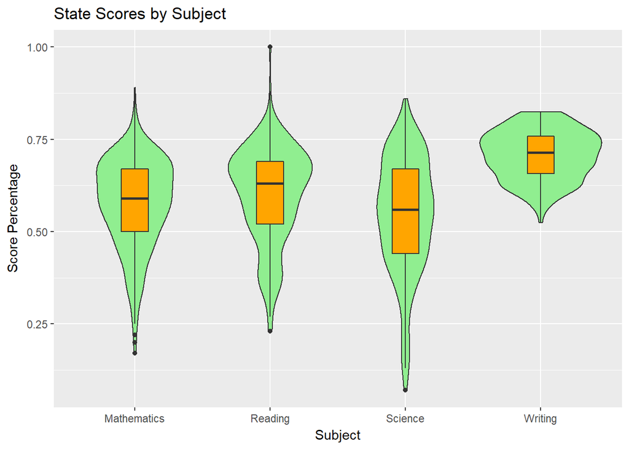

```r
p1 <- ggplot(subjectlist[[3]], aes(x=Subject, y=Standard.Correct.Percent))+
  geom_violin(fill='lightgreen')+
  geom_boxplot(fill="orange",width=0.2)+
  ggtitle("State Scores by Subject")+
  labs(x="Subject", y="Score Percentage");
```

#Plots the Boxplot and violin plot for State level, by Student Demographic

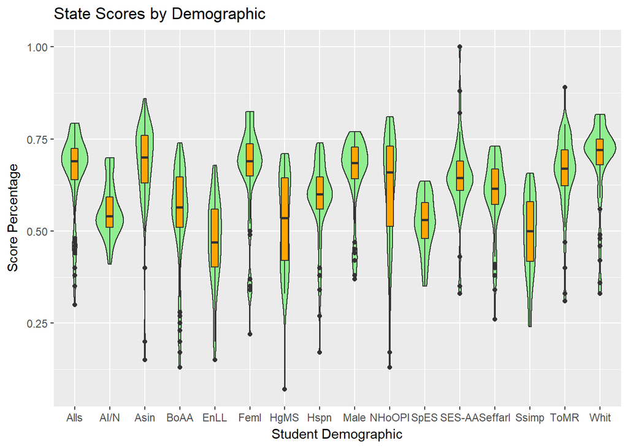

```r
p2 <- ggplot(subjectlist[[3]], aes(x=AYP.Group, y=Standard.Correct.Percent))+
  geom_violin(fill='lightgreen')+
  geom_boxplot(fill="orange",width=0.2)+
  ggtitle("State Scores by Demographic")+
  labs(x="Student Demographic", y="Score Percentage")+
  scale_x_discrete(labels = abbreviate);
```